# Tuna longline targeting: flat versus contrasting true trends

Henning Winker FAO Fisheries and Aquaculture Division, Assessment and Management Team (NFIFM) henning.winker@fao.org

In a tuna longline fishery, skippers target species not only through *where* they fish but also through *how deep* they set their hooks, which depends on the number of hooks between floats (HBF) and on the depth of the thermocline. This vignette compares the standardisation methods in two scenarios with **identical targeting** that differ only in the true trends:

| Scenario | Stocks | True trends |
| --- | --- | --- |
| **Flat** | unfished at the start, lightly fished (`q = 0.2`, `B_start = 1`) | nearly flat |
| **Contrasting** | partly fished at the start, fished harder (package defaults) | diverging between species: BFT recovers, BET declines, … |

With flat trends, every change in the catch composition is caused by targeting. With contrasting trends, the composition also changes because the species’ relative abundances change.

Positions are reported as 5 x 5 blocks: logbooks rarely report positions at the scale at which fish and fleets interact, and a longline set may span a front. The thermocline moves between years in the results shown here (`Moving`); results for a fixed thermocline are in the replicates.

# Settings

```r
prices <- matrix(c(rep(c(0.3, 0.2, 1.0, 2.0), 10),   # years 1-10: ALB (+ BFT)
                   rep(c(1.5, 2.5, 0.7, 0.3), 10),   # years 11-20: BET (+ YFT)
                   rep(c(1.0, 2.0, 1.5, 0.5), 10)),  # years 21-30: BET / BFT
                 ncol = 4, byrow = TRUE)             # columns: YFT, BET, BFT, ALB
contrast_settings <- tuna_settings()
contrast_settings$price <- prices
flat_settings <- modifyList(contrast_settings, list(q = 0.2, B_start = rep(1, 4)))
moving <- list(thermocline_annual_sd = 15, thermocline_annual_field_sd = 10)

with_thermocline <- function(s) list(Fixed = s, Moving = modifyList(s, moving))

models <- c("Base", "Base+S", "Cluster+S", "DPC+S", "HBF+S")

# Standardisation: 5 models, plus DPC+S with 2 PCs
fit_one <- function(sim) {
  fit <- standardize_cpue(sim, models = models, spatial_res = 5, n_pc = 3,
                          engine = "bam")
  fit_2pc <- standardize_cpue(sim, models = "DPC+S", n_pc = 2,
                              label = " (2 PCs)", engine = "bam")
  bind_comparisons(fit, fit_2pc)
}
# One scenario: simulations and fits for a fixed and a moving thermocline
run_single <- function(s, seed = 123) {
  sims <- lapply(with_thermocline(s), simulate_tuna, seed = seed, plots = FALSE)
  list(sims = sims, fits = lapply(sims, fit_one))
}
```

`flat` and `contrast` each hold `sims` and `fits` for the `Fixed` and `Moving` thermocline, e.g. `flat$sims$Moving` and `flat$fits$Moving`. The pre-run results from `inst/scripts/run_tuna_flat.R` and `run_tuna_contrast.R` are exactly these objects:

```r
flat <- run_single(flat_settings)
contrast <- run_single(contrast_settings)
```

The prices switch the fleet from the cool south (ALB) to the warm north (BET) in year 11, which changes both where and how deep it fishes, and split it between BET in the north and BFT in the south in year 21, which changes only where it fishes.

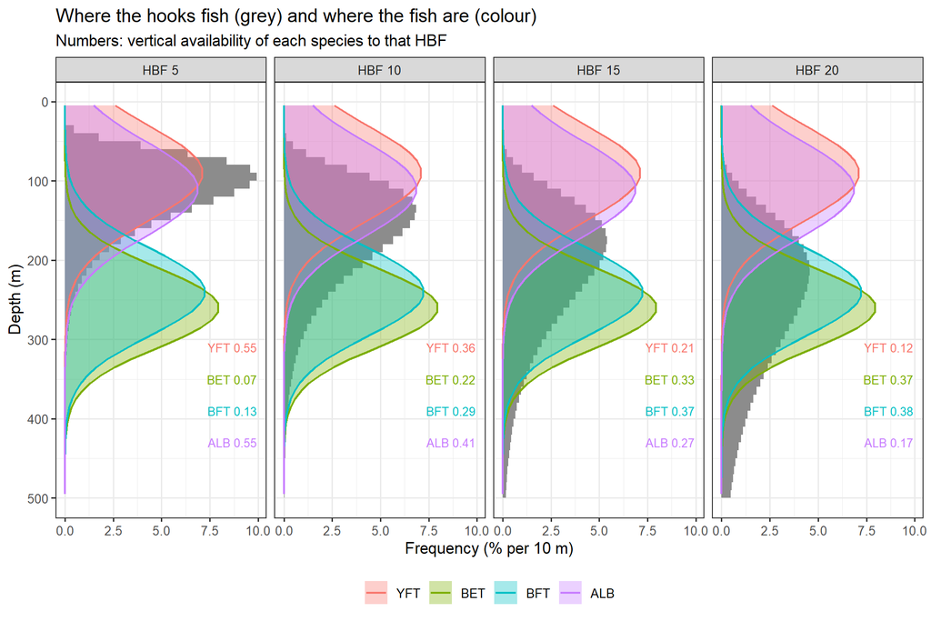

```r
plot_tuna_vertical_distributions()
```

In the Moving scenario the basin-wide thermocline goes up and down between years, and the spatial pattern changes on top of it:

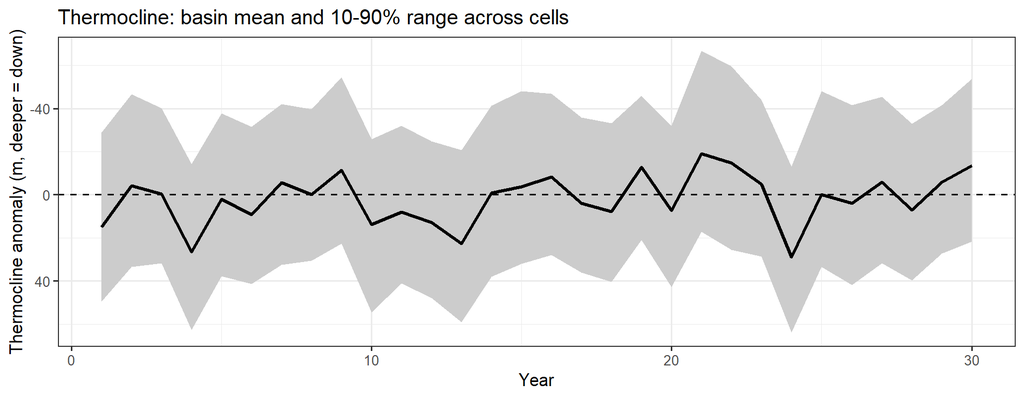

```r
plot_thermocline(contrast$sims$Moving)$series
```

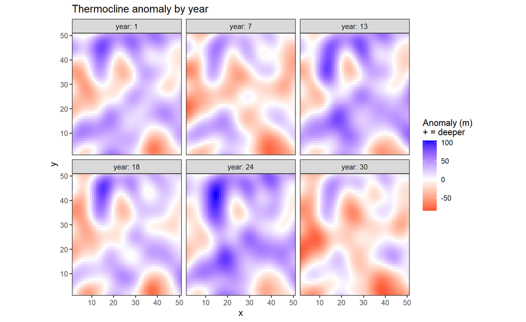

```r
plot_thermocline(contrast$sims$Moving)$maps
```

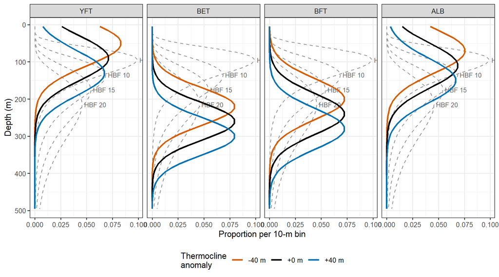

```r
plot_thermocline_effect()
```

# Nominal CPUE versus the truth

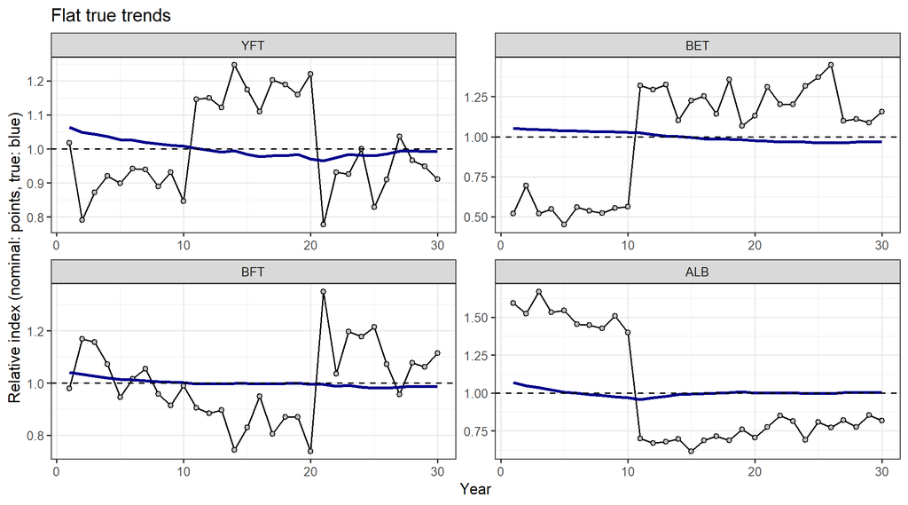

```r
plot_om(flat$sims$Moving)$CPUE + ggtitle("Flat true trends")
```

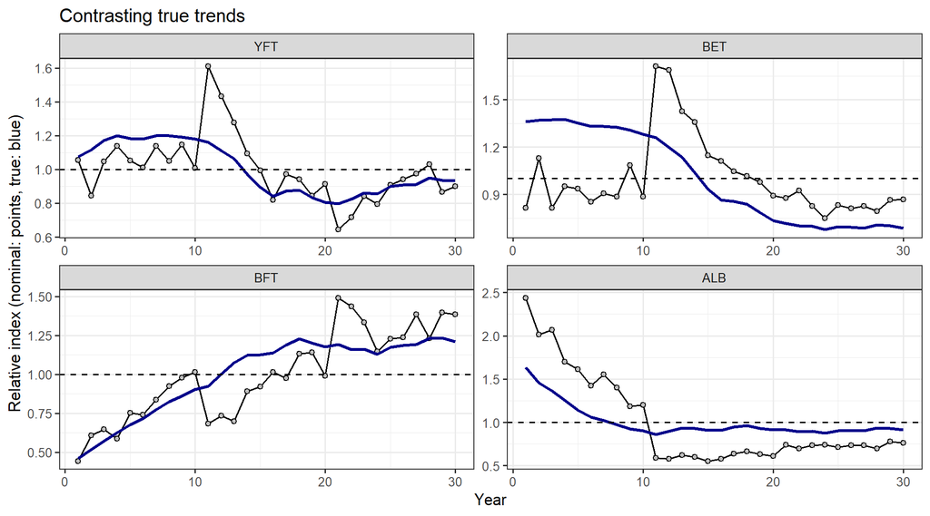

```r
plot_om(contrast$sims$Moving)$CPUE + ggtitle("Contrasting true trends")
```

The same targeting produces jumps in nominal CPUE at years 11 and 21 in both scenarios; only the true trends (blue) differ.

# Standardised indices

All models are Tweedie GAMs with `year` plus a targeting term (`+S`: spatial smoother on the 5 x 5 blocks): Base (none), Cluster (4 clusters of the catch composition), DPC (3 principal components, and 2 for comparison) and HBF (a factor for the gear).

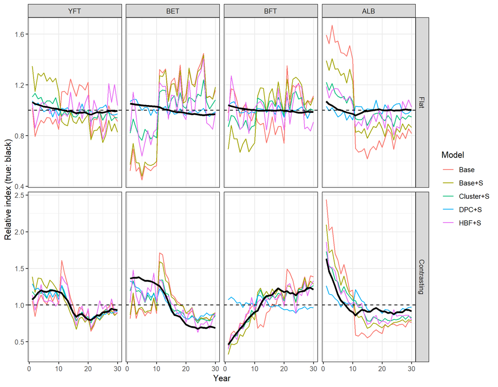

```r
fits <- list(Flat = flat$fits$Moving, Contrasting = contrast$fits$Moving)
plot_indices(fits, models = models)
```

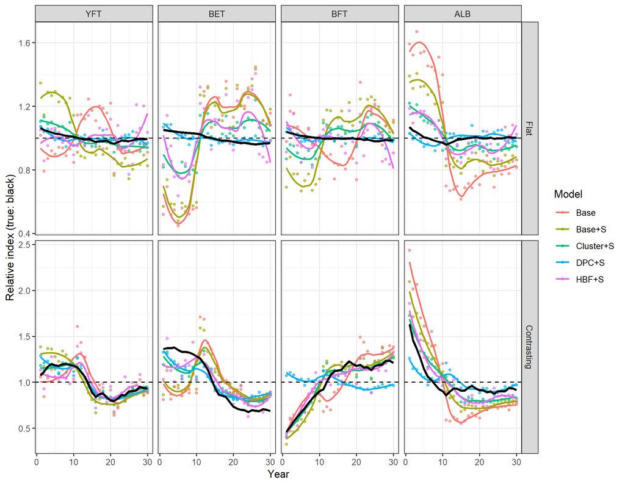

```r
plot_indices(fits, models = models, type = "points+smooth")
```

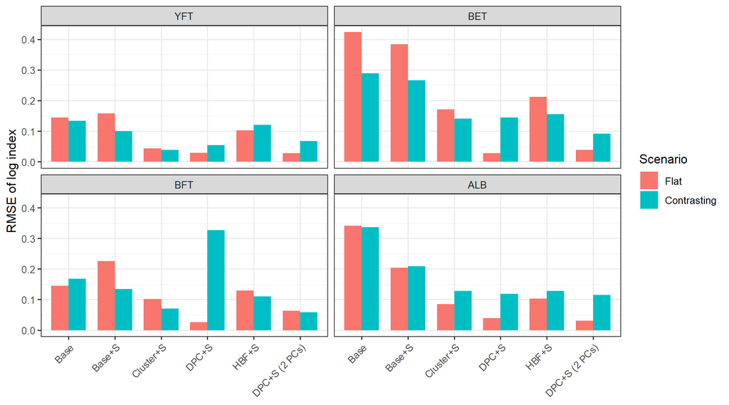

```r
plot_diagnostics(fits)
```

With diverging trends the number of PCs matters. The contrasting scenario with 2 PCs and 4 clusters: DPC is best where targeting is gradual or vertical (BET), clusters where tactics switch between water masses (YFT).

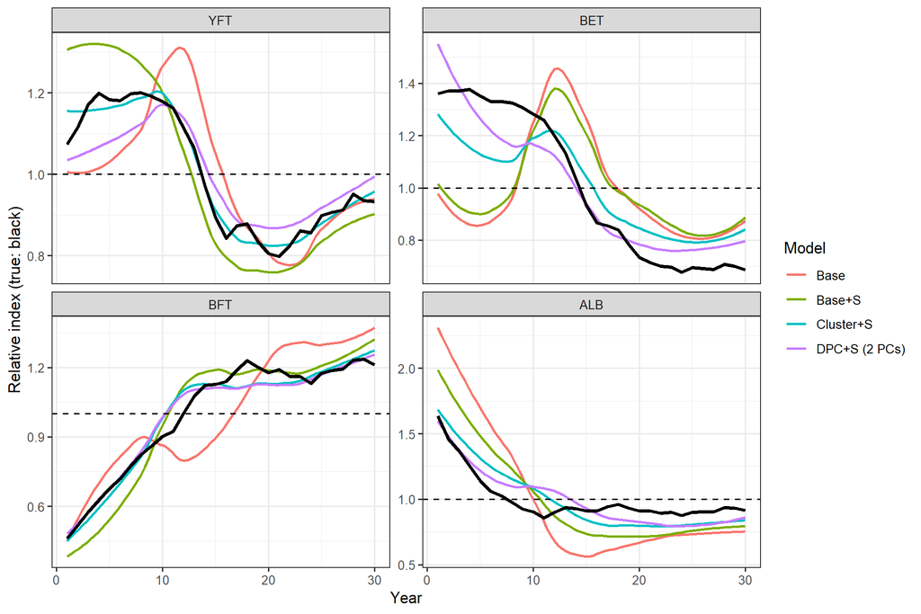

```r
plot_indices(select_models(contrast$fits$Moving,
                           c("Base", "Base+S", "Cluster+S", "DPC+S (2 PCs)")),
             type = "smooth")
```

# What do the PCs capture?

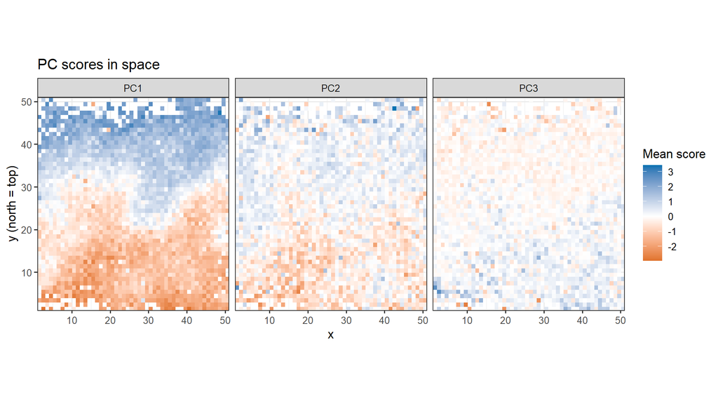

```r
pp <- plot_pcs(flat$fits$Moving, pcs = c("PC1", "PC2", "PC3"))
pp$space
```

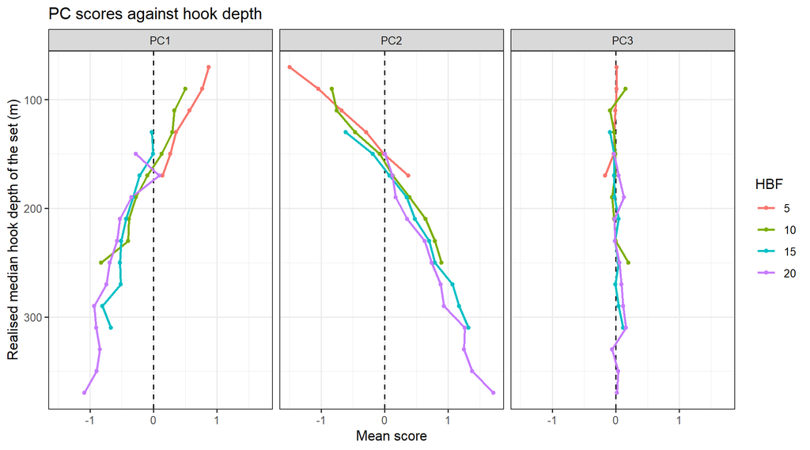

```r
pp$depth
```

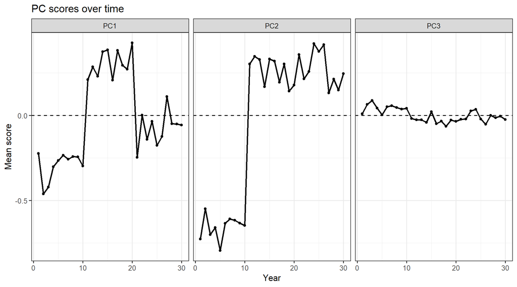

```r
pp$time
```

PC1 is the north-south gradient (where), PC2 the depth of the hooks (how deep): the PCA separates spatial and vertical targeting without being told that depth exists. With flat trends, the PCs change only in steps at the price switches. With contrasting trends, a gradual drift is added as the species’ relative abundances change:

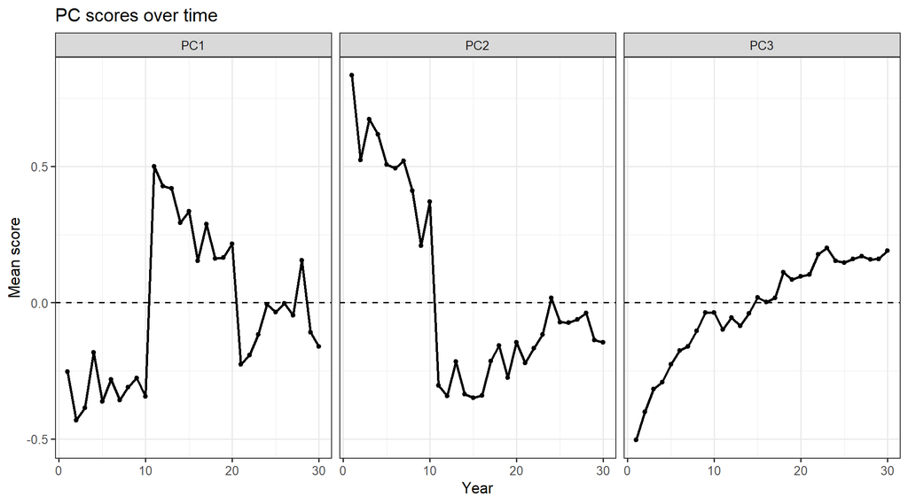

```r
plot_pcs(contrast$fits$Moving, pcs = c("PC1", "PC2", "PC3"))$time
```

# What do the clusters capture?

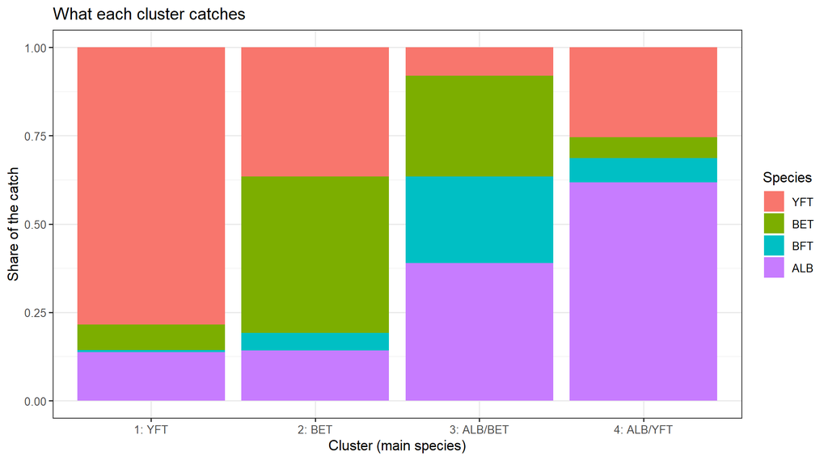

```r
pc <- plot_clusters(flat$fits$Moving, switch_years = c(10.5, 20.5))
pc$composition
```

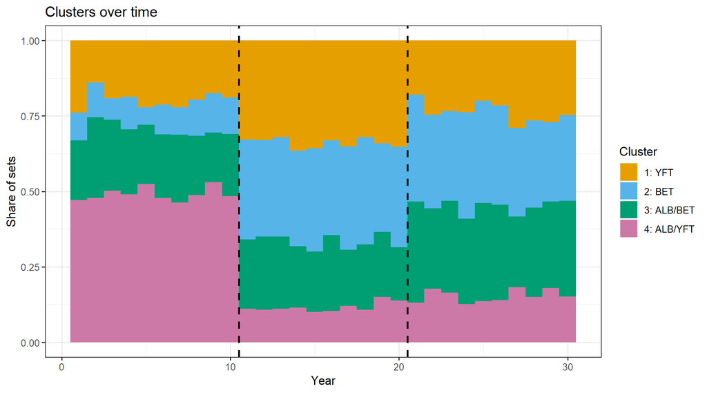

```r
pc$time
```

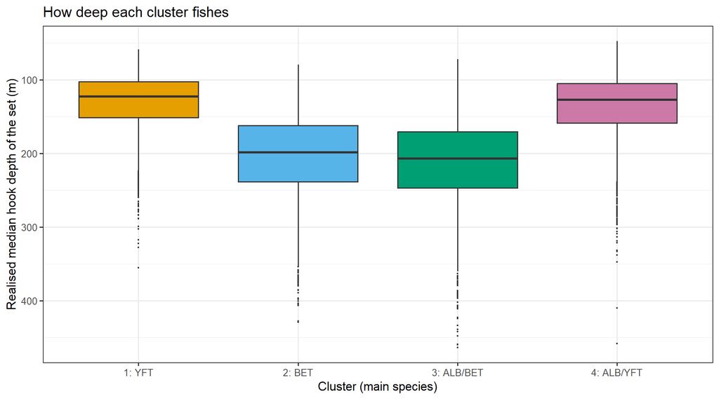

```r
pc$depth
```

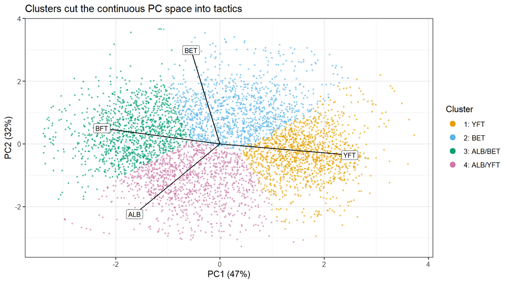

```r
pc$pca
```

# Replicates: flat versus contrasting trends

20 seeds of each scenario, with a fixed and a moving thermocline (`inst/scripts/run_tuna_flat.R` and `run_tuna_contrast.R`):

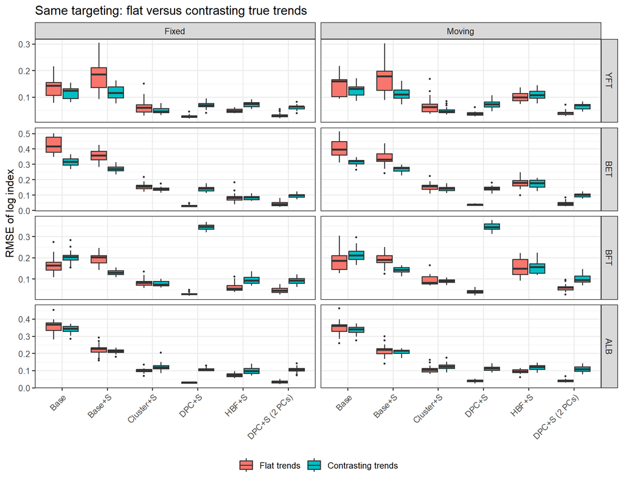

```r
reps <- rbind(
  data.frame(readRDS(files[["flat_reps"]])$diagnostics, trend = "Flat trends"),
  data.frame(readRDS(files[["contrast_reps"]])$diagnostics, trend = "Contrasting trends"))
reps$trend <- factor(reps$trend, levels = c("Flat trends", "Contrasting trends"))
reps$model <- factor(reps$model, levels = unique(as.character(reps$model)))

ggplot(reps, aes(x = model, y = rmse_log, fill = trend)) +
  geom_boxplot(outlier.size = 0.6) +
  facet_grid(species ~ scenario, scales = "free_y") +
  labs(x = NULL, y = "RMSE of log index", fill = NULL,
       title = "Same targeting: flat versus contrasting true trends") +
  theme_bw() +
  theme(axis.text.x = element_text(angle = 45, hjust = 1), legend.position = "bottom")
```

# What to take from this

- **Space fixes *where*, not *how deep*.** The spatial term removes much of the bias from the north-south switches, but not the vertical targeting of BET.
- **HBF works only while the depth of the fish is stable.** With a moving thermocline, the same HBF fishes at different depths relative to the fish each year.
- **The catch composition captures both**, because it reflects where and how deep each set actually fished. With flat trends, DPC is close to the truth for all species.
- **But the catch composition also carries abundance.** When species’ relative abundances change persistently, the PCs absorb part of the real trend of the species whose relative abundance changes most, and more PCs absorb more. Coarser, discrete clusters are less affected.
- Plotting the PCs over time helps to tell the two apart: targeting changes are steps at known changes in the fishery, abundance changes are gradual.